# EDA(3) - Inference

Rafe C. H. Liu

Feb 2, 2015 @ DSP

Contact me｜ [Data Analyst Training Program @ DSP](http://dsp.im/events/a1-basic-data-analysis-course/)

# Code Demo 3

### Settings

```r
# Settings
library(ggplot2); library(reshape2); library(psych); library(dplyr)
# Windows
# setwd("C:/Users/ABACUS/Desktop/Dropbox/~OnGoing/20150131 A1")
# MAC
setwd("~Rafe/Dropbox/~OnGoing/20150131 A1")

# List files
# list.files()

# Read
# Windows
# bike <- read.csv(file="ubike-big5.csv", header = TRUE)

# MAC
# bike <- read.csv(file="ubike-utf8.csv", header = TRUE)

load("ana_bike2.RDA")
```

### Tips

- `#` 筆記法
- 統計資源
  - [國立台灣大學統計教學中心](http://www.statedu.ntu.edu.tw/lecture/index.asp)
  - [中國醫藥大學 生物統計中心 生統e報](http://www2.cmu.edu.tw/~biostat/epaper/paper_040.html)
  - [中國醫藥大學 雲端資料分析暨導引系統](http://www.r-web.com.tw/index.php)

# Normal Distribution

### Probability Distributions

- “d” returns the height of the probability density function
- “p” returns the cumulative density function
- “q” returns the inverse cumulative density function (quantiles)
- “r” returns randomly generated numbers
  - [Probability Plots](http://www.statmethods.net/advgraphs/probability.html)
  - [Basic Probability Distributions](http://www.cyclismo.org/tutorial/R/probability.html)

```r
pnorm(1.96) # Probability
```

```
## [1] 0.9750021
```

```r
qnorm(0.025) # alpha
```

```
## [1] -1.959964
```

```r
rnorm(10) # random numbers
```

```
##  [1] -0.4946926 -0.9371341 -0.7681657  0.3796987  3.4233734 -0.4652625
##  [7]  0.1813511 -1.7005010 -0.1157306  0.2214736
```

### Funtion curve - Z

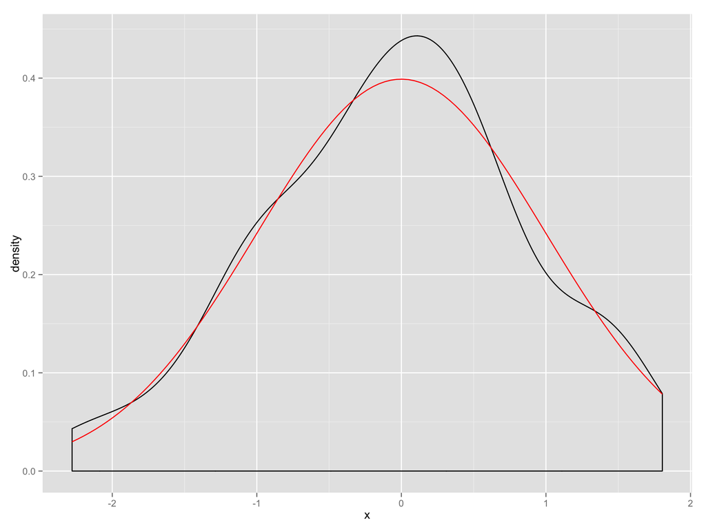

```r
x <- rnorm(100)
qplot(x, geom = "density") +
  stat_function(fun = dnorm, colour = "red")
```

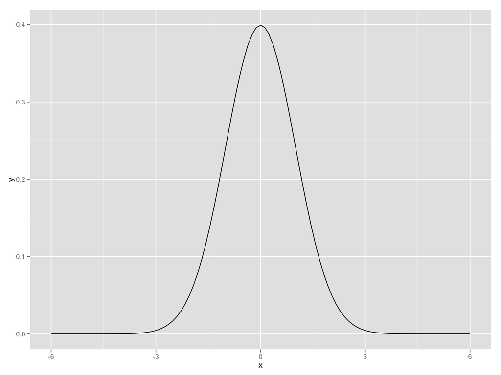

```r
ggplot(data.frame(x = c(-6, 6)), aes(x)) +
  stat_function(fun = dnorm)
```

Example DEMO:

> Children’s IQ scores are normally distributed with a mean of 100 a nd a standard deviation of 15. What proportion of children are expected to have an IQ between 80 and 120?

```r
mean=100; sd=15
lb=80; ub=120

x <- seq(-4,4,length=100)*sd + mean
hx <- dnorm(x,mean,sd)

plot(x, hx, type="l", xlab="IQ Values", ylab="", main="Normal Distribution", axes=FALSE)

i <- x >= lb & x <= ub
lines(x, hx)
polygon(c(lb,x[i],ub), c(0,hx[i],0), col="red")

# Probability - upper bound
pnorm(ub, mean, sd)
```

```
## [1] 0.9087888
```

```r
# Probability - lower bound
pnorm(lb, mean, sd)
```

```
## [1] 0.09121122
```

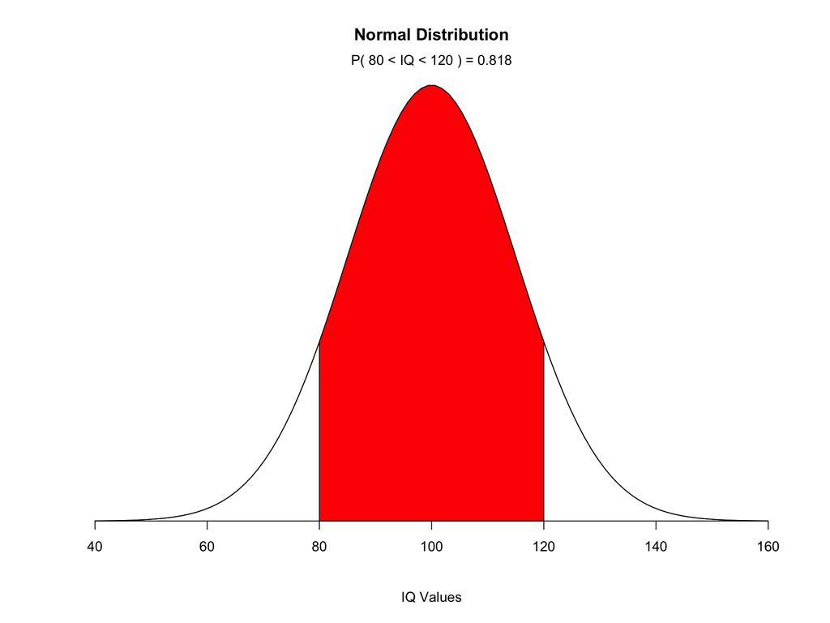

```r
area <- pnorm(ub, mean, sd) - pnorm(lb, mean, sd)
result <- paste("P(",lb,"< IQ <",ub,") =",
   signif(area, digits=3))
mtext(result,3)
axis(1, at=seq(40, 160, 20), pos=0)
```